# ENV 790.30 - Time Series Analysis for Energy Data | Spring 2023

Assignment 7 - Due date 03/20/23

Kexin(Kassie) Huang

## Directions

You should open the .rmd file corresponding to this assignment on RStudio. The file is available on our class repository on Github. And to do so you will need to fork our repository and link it to your RStudio.

Once you have the file open on your local machine the first thing you will do is rename the file such that it includes your first and last name (e.g., “LuanaLima_TSA_A07_Sp23.Rmd”). Then change “Student Name” on line 4 with your name.

Then you will start working through the assignment by **creating code and output** that answer each question. Be sure to use this assignment document. Your report should contain the answer to each question and any plots/tables you obtained (when applicable).

When you have completed the assignment, **Knit** the text and code into a single PDF file. Submit this pdf using Sakai.

## Set up

```r
#Load/install required package here
library(lubridate)
```

```r
library(ggplot2)
library(forecast)
library(Kendall)
library(tseries)
library(outliers)
library(tidyverse)
library(cowplot)
```

## Importing and processing the data set

Consider the data from the file “Net_generation_United_States_all_sectors_monthly.csv”. The data corresponds to the monthly net generation from January 2001 to December 2020 by source and is provided by the US Energy Information and Administration. **You will work with the natural gas column only**.

Packages needed for this assignment: “forecast”,“tseries”. Do not forget to load them before running your script, since they are NOT default packages.\

### Q1

Import the csv file and create a time series object for natural gas. Make you sure you specify the **start=** and **frequency=** arguments. Plot the time series over time, ACF and PACF.

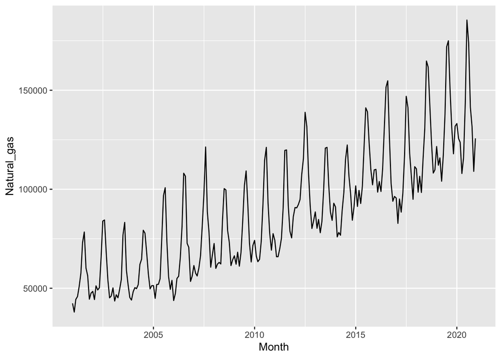

```r
#import the csv
read_data <- read.csv(file='./Data/Net_generation_United_States_all_sectors_monthly.csv',header = TRUE, skip = 4)

#fix the reversed order
data_processed <-
  data.frame(Month=my(read_data$Month), Natural_gas=read_data$natural.gas.thousand.megawatthours) %>%
  arrange(Month)
my_date <- data_processed$Month

#create a time series object
ts_natural_gas <- ts(
  data_processed$Natural_gas,
  start=c(year(my_date[1]),month(my_date[1])),
  frequency = 12)

#plot the series, ACF and PACF
plot(ggplot(data = data_processed, aes(x=Month,y=Natural_gas))+
  geom_line()
  )
```

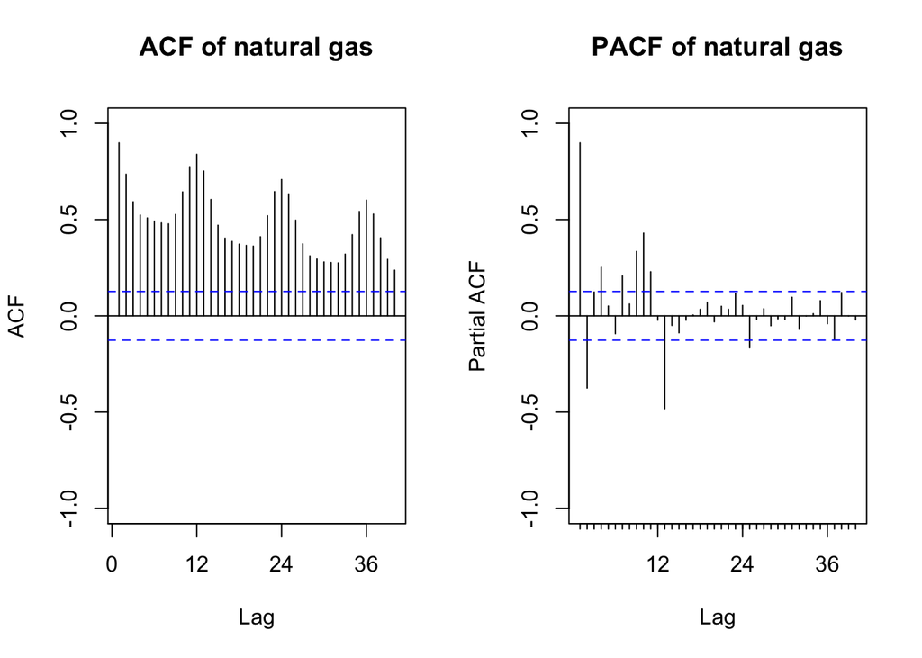

```r
par(mfrow=c(1,2))
Acf(ts_natural_gas,lag.max = 40, ylim=c(-1,1),main="ACF of natural gas")
Pacf(ts_natural_gas,lag.max = 40, ylim=c(-1,1),main="PACF of natural gas")
```

### Q2

Using the $decompose()$ or $stl()$ and the $seasadj()$ functions create a series without the seasonal component, i.e., a deseasonalized natural gas series. Plot the deseasonalized series over time and corresponding ACF and PACF. Compare with the plots obtained in Q1.

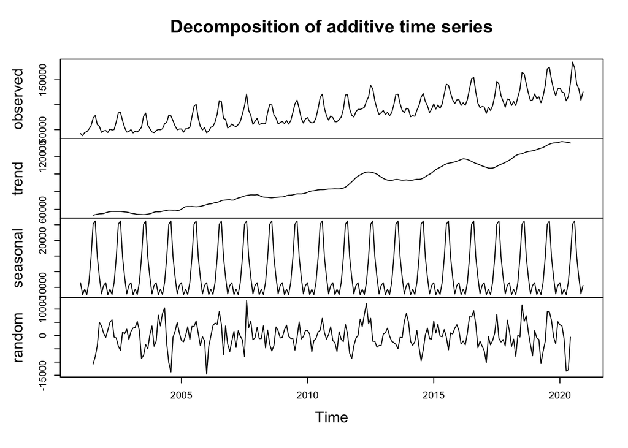

```r
#decompose the time series
decompose_natural_gas <- decompose(ts_natural_gas,type="additive")
plot(decompose_natural_gas)
```

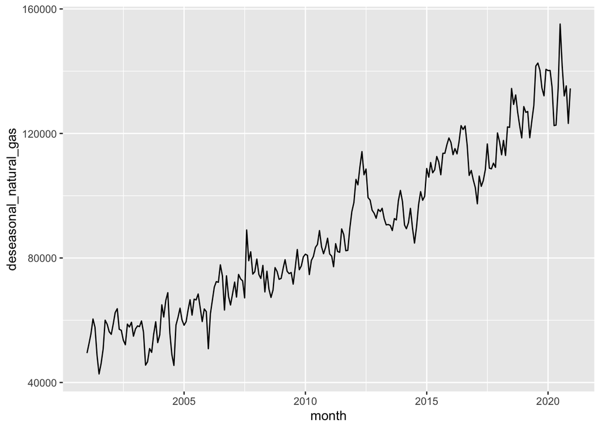

```r
#deseason the time series
deseasonal_natural_gas <- seasadj(decompose_natural_gas)
df_deseasonal <- data.frame(month=my_date,deseasonal_natural_gas=deseasonal_natural_gas)
#plot the deseasoned series and its ACF, PACF
plot(ggplot(df_deseasonal,aes(x=month,y=deseasonal_natural_gas))+
       geom_line()
)
```

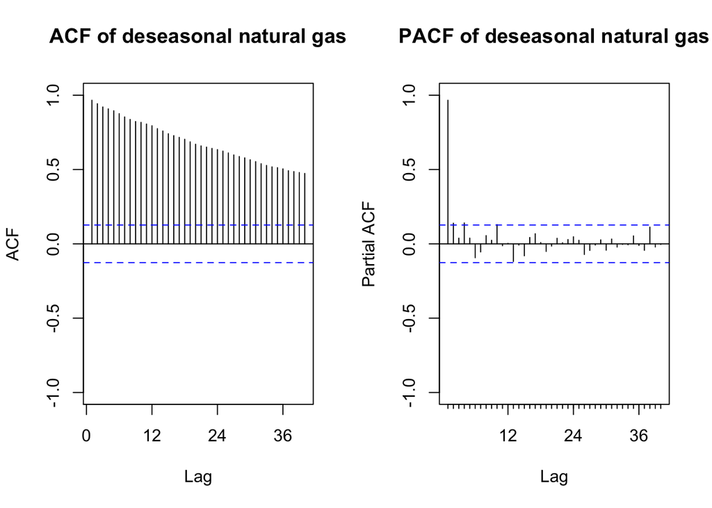

```r
par(mfrow=c(1,2))
Acf(deseasonal_natural_gas,lag.max = 40, ylim=c(-1,1),main="ACF of deseasonal natural gas")
Pacf(deseasonal_natural_gas,lag.max = 40, ylim=c(-1,1),main="PACF of deseasonal natural gas")
```

Compared to the plots in Q1, the seasonal component is less pronounced in all three plots: the seasonal peaks in the original time series plot are now removed; the seasonal waveform patterns in the original ACF plot are also removed, leaving only a monotonically decreasing trend; the spikes around lag 12, 24 in the original PACF plot are removed.

## Modeling the seasonally adjusted or deseasonalized series

### Q3

Run the ADF test and Mann Kendall test on the deseasonalized data from Q2. Report and explain the results.

```r
#Run ADF
print(adf.test(deseasonal_natural_gas,alternative = "stationary"))
```

```
##
##  Augmented Dickey-Fuller Test
##
## data:  deseasonal_natural_gas
## Dickey-Fuller = -4.0271, Lag order = 6, p-value = 0.01
## alternative hypothesis: stationary
```

The p-value is 0.01, so we reject the null hypothesis that the time series contains a unit root. In other words, the original time series does not have a stochastic trend.

```r
#Run Mann Kendall
print(MannKendall(deseasonal_natural_gas))
```

```
## tau = 0.843, 2-sided pvalue =< 2.22e-16
```

The p-value is 2.22e-16, so we reject the null hypothesis that the time series is stationary. In other words, the original time series follows a trend.

### Q4

Using the plots from Q2 and test results from Q3 identify the ARIMA model parameters $p,d$ and $q$. Note that in this case because you removed the seasonal component prior to identifying the model you don’t need to worry about seasonal component. Clearly state your criteria and any additional function in R you might use. DO NOT use the $auto.arima()$ function. You will be evaluated on ability to can read the plots and interpret the test results.

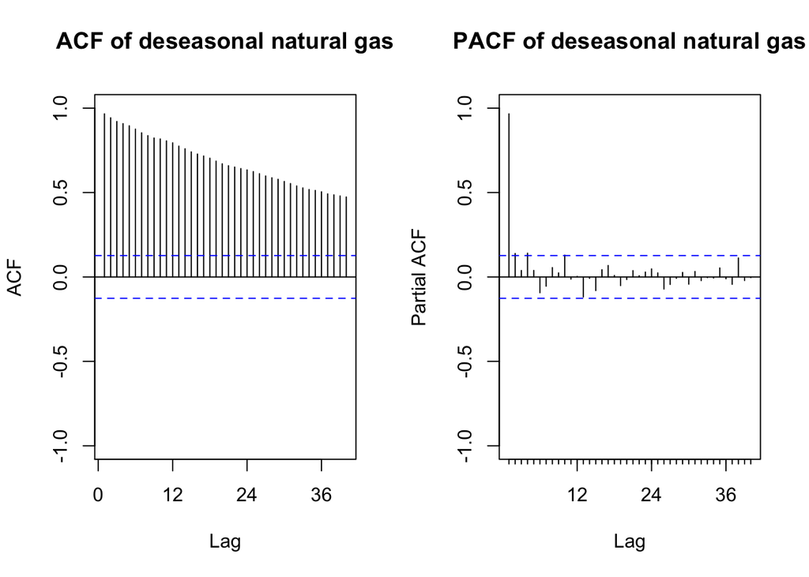

```r
#plot the ACF and PACF again
par(mfrow=c(1,2))
Acf(deseasonal_natural_gas,lag.max = 40, ylim=c(-1,1),main="ACF of deseasonal natural gas")
Pacf(deseasonal_natural_gas,lag.max = 40, ylim=c(-1,1),main="PACF of deseasonal natural gas")
```

Looking at the ACF and PACF plots, this time series contains mainly an AR process: the ACF decays slowly, while the PACF shows a cut-off at lag=2.

Regarding $d$, the result of the Mann-Kendall test shows that the time series follows a trend. Therefore, d should be at least 1. To further confirm if d=1 is enough, use $ndiffs()$ function:

```r
#examine if d=1 is enough
n_diff <- ndiffs(deseasonal_natural_gas)
cat("Number of differencing needed: ",n_diff)
```

```
## Number of differencing needed:  1
```

As shown by the result, d=1 is enough. To sum up, all the parameters for the ARIMA model are: $p=2,d=1,q=0$ .

### Q5

Use $Arima()$ from package “forecast” to fit an ARIMA model to your series considering the order estimated in Q4. You should allow constants in the model, i.e., $include.mean = TRUE$ or $include.drift=TRUE$. **Print the coefficients** in your report. Hint: use the $cat()$ function to print.

```r
Model_210 <- Arima(deseasonal_natural_gas,order=c(2,1,0),include.drift=TRUE)
print(Model_210$coef)
```

```
##         ar1         ar2       drift
##  -0.1647241  -0.1283009 346.8289070
```

### Q6

Now plot the residuals of the ARIMA fit from Q5 along with residuals ACF and PACF on the same window. You may use the $checkresiduals()$ function to automatically generate the three plots. Do the residual series look like a white noise series? Why?

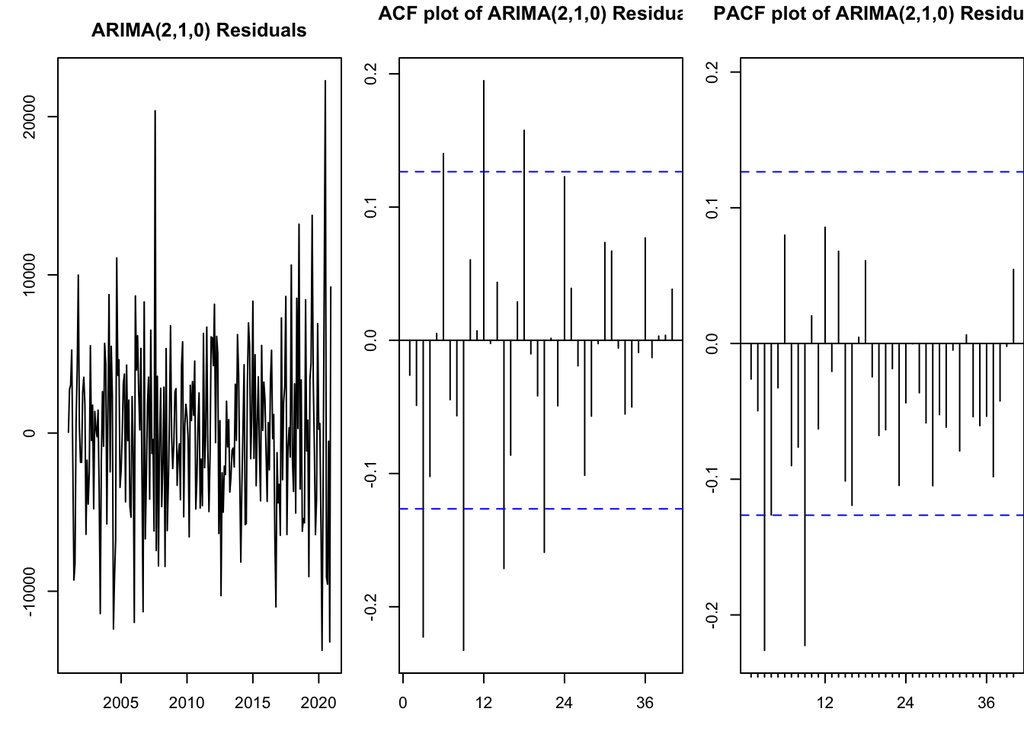

```r
par(mar=c(3,3,3,0));par(mfrow=c(1,3))
ts.plot(Model_210$residuals,ylab="residuals",main="ARIMA(2,1,0) Residuals")
Acf(Model_210$residuals,lag.max=40, main="ACF plot of ARIMA(2,1,0) Residuals")
Pacf(Model_210$residuals,lag.max=40, main="PACF plot of ARIMA(2,1,0) Residuals")
```

Looking only at the ts plot, it’s hard to tell if the residual series doesn’t look like a white noise series.

However, by definition, the white noise series should be completely random and i.i.d. Thus, a white noise series will not exhibit an autocorrelation pattern, and all values in the ACF or PACF plot should be within the significant level after lag=0. Therefore, the many spikes in the ACF and PACF plots beyond the significant level indicate that this series is not a white noise series.

## Modeling the original series (with seasonality)

### Q7

Repeat Q4-Q6 for the original series (the complete series that has the seasonal component). Note that when you model the seasonal series, you need to specify the seasonal part of the ARIMA model as well, i.e., $P$, $D$ and $Q$.

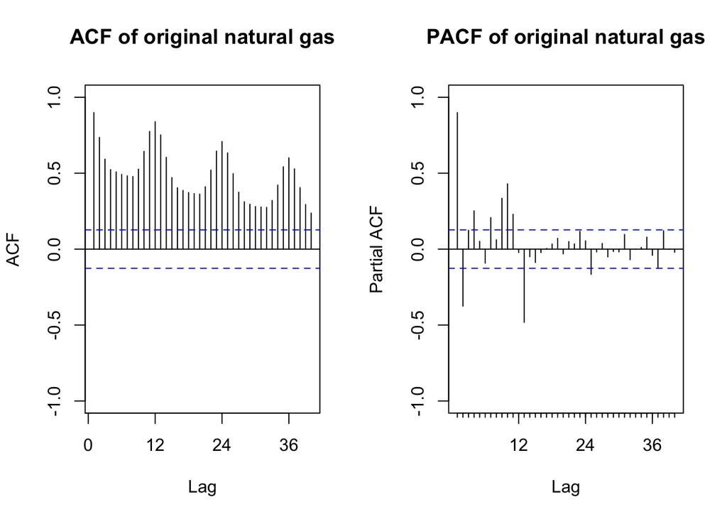

```r
#plot the ACF and PACF for the original series
par(mfrow=c(1,2))
Acf(ts_natural_gas,lag.max = 40, ylim=c(-1,1),main="ACF of original natural gas")
Pacf(ts_natural_gas,lag.max = 40, ylim=c(-1,1),main="PACF of original natural gas")
```

Looking at the Acf and Pacf plot (lag = 1 to 11), we can first determine the same *p=2,q=0* before, because of the slow decay in ACF plot and the cut-off at lag=2 in PACF plot. As for P and Q, because the autocorrelation at the seasonal period is positive, we should consider adding an SAR term to the model, i.e. $P=1,Q=0$.

```r
#determine d and D
ndiffs(ts_natural_gas,max.d=2)
```

```
## [1] 1
```

```r
nsdiffs(ts_natural_gas,max.D=1)
```

```
## [1] 1
```

Therefore, $d=1,D=1$. To sum up, the parameters of the SARIMA model are as follows: $p=2,d=1,q=0,P=1,D=1,Q=0$.

### Q8

Compare the residual series for Q7 and Q6. Can you tell which ARIMA model is better representing the Natural Gas Series? Is that a fair comparison? Explain your response.

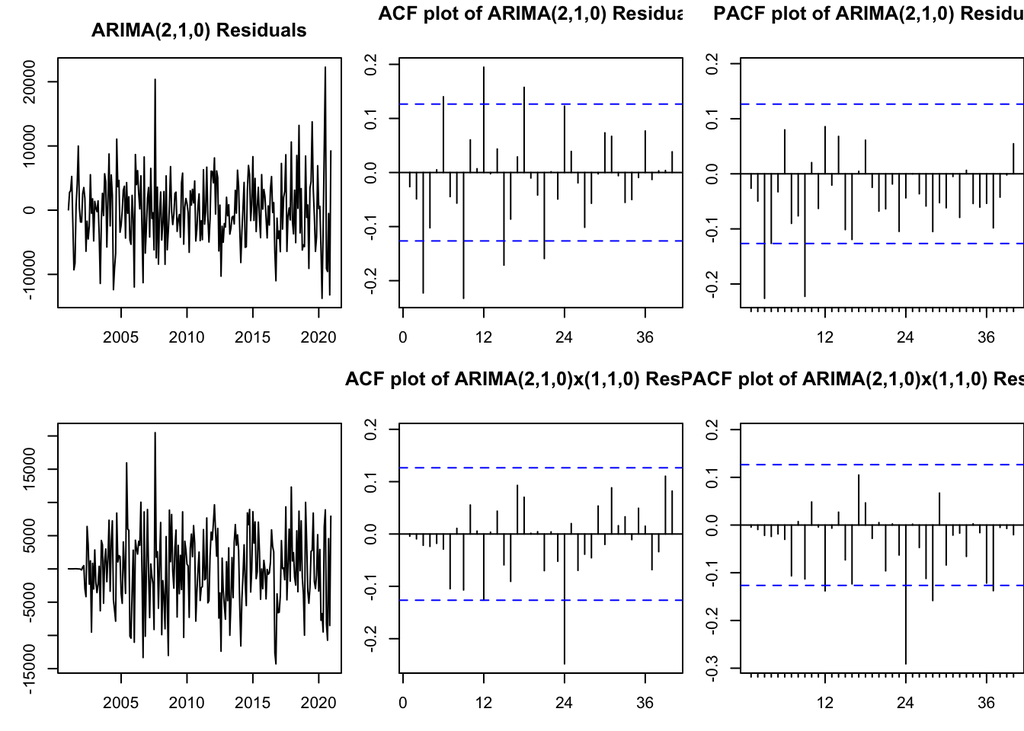

```r
SARIMA_210_110 <-
  Arima(ts_natural_gas,order=c(2,1,0),seasonal=c(1,1,0),include.drift = FALSE)

#compare the two residual series
par(mar=c(3,3,3,0));par(mfrow=c(2,3))
#ARIMA(2,1,0)
ts.plot(Model_210$residuals,ylab="residuals",main="ARIMA(2,1,0) Residuals")
Acf(Model_210$residuals,lag.max=40, main="ACF plot of ARIMA(2,1,0) Residuals")
Pacf(Model_210$residuals,lag.max=40, main="PACF plot of ARIMA(2,1,0) Residuals")
#SARIMA(2,1,0)x(1,1,0)
ts.plot(SARIMA_210_110$residuals)
Acf(SARIMA_210_110$residuals,lag.max=40,main="ACF plot of ARIMA(2,1,0)x(1,1,0) Residuals")
Pacf(SARIMA_210_110$residuals,lag.max=40,main="PACF plot of ARIMA(2,1,0)x(1,1,0) Residuals")
```

However, the ARIMA(2,1,0) model and the SARIMA(2,1,0)x(1,1,0) model represent different time series - the former represents the deseasoned series while the latter represents the original series - it might be unfair to compare the two residual series.

## Checking your model with the auto.arima()

**Please** do not change your answers for Q4 and Q7 after you ran the $auto.arima()$. It is **ok** if you didn’t get all orders correctly. You will not loose points for not having the same order as the $auto.arima()$.

### Q9

Use the $auto.arima()$ command on the **deseasonalized series** to let R choose the model parameter for you. What’s the order of the best ARIMA model? Does it match what you specified in Q4?

```r
auto_ARIMA <- auto.arima(deseasonal_natural_gas)
print(auto_ARIMA)
```

```
## Series: deseasonal_natural_gas
## ARIMA(1,1,1) with drift
##
## Coefficients:
##          ar1      ma1     drift
##       0.7065  -0.9795  359.5052
## s.e.  0.0633   0.0326   29.5277
##
## sigma^2 = 26980609:  log likelihood = -2383.11
## AIC=4774.21   AICc=4774.38   BIC=4788.12
```

The parameter it chooses is $p=1,d=1,q=1$. The $d$ is same as mine, but $p,q$ is different from my choice.

### Q10

Use the $auto.arima()$ command on the **original series** to let R choose the model parameters for you. Does it match what you specified in Q7?

```r
auto_SARIMA <- auto.arima(ts_natural_gas)
print(auto_SARIMA)
```

```
## Series: ts_natural_gas
## ARIMA(1,0,0)(0,1,1)[12] with drift
##
## Coefficients:
##          ar1     sma1     drift
##       0.7416  -0.7026  358.7988
## s.e.  0.0442   0.0557   37.5875
##
## sigma^2 = 27569124:  log likelihood = -2279.54
## AIC=4567.08   AICc=4567.26   BIC=4580.8
```